# OpenAlexR

OpenAlex est accessible via son site web : https://openalex.org/, par l’intermédiaire de moteurs de bases de données (tels que Google BigQuery) ou en utilisant l’[API](https://docs.openalex.org/how-to-use-the-api/api-overview).

## Qu’est-ce qu’une API ?

Une API (*Application Programming Interface*) est un ensemble de règles et d’outils permettant à différentes applications logicielles de communiquer entre elles. Elle définit la structure des requêtes et des réponses afin qu’un système puisse accéder aux données d’un autre système et les utiliser.

Dans notre cas, nous allons *envoyer des requêtes* à https://api.openalex.org/ et recevoir *la réponse* (les données).

[figure not shown]

## Utilisation de R

Nous ne couvrirons pas toutes les possibilités qu’offre R, car elles sont trop nombreuses[^1].

R est un *langage de programmation* que nous exécuterons via une interface (RStudio). Le *code* peut être exécuté dans le terminal, dans un script (un fichier .R) ou dans un fichier .qmd comme celui-ci, où nous avons des *blocs de code* 👇

```r
1+1
```

```
[1] 2
```

En tant que langage, R dispose de commandes que nous pouvons exécuter. Ces commandes peuvent être étendues grâce à des *packages* (extensions du langage).

**OpenAlexR** est un package conçu pour servir d’interface entre l’API OpenAlex et R.

```r
library(tidyverse)
library(openalexR)
```

## Structure

La fonction principale que nous utiliserons est `oa_fetch`, qui permet de récupérer les données et de les transformer en un format R (dataframe).

OpenAlex est structuré en plusieurs tables, qui représentent différentes **unités d’analyse**. Nous devons préciser le type d’information recherché en indiquant l’**entité** correspondante.

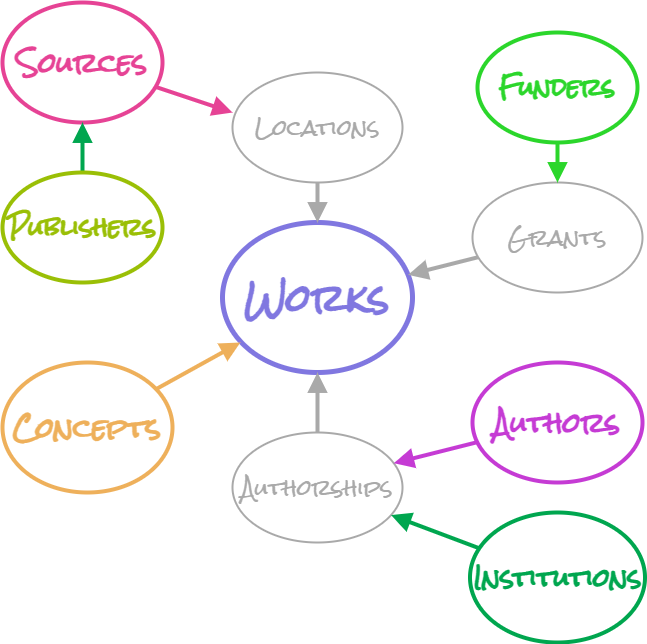

- [Works](https://docs.openalex.org/api-entities/works) : Documents scientifiques tels que des articles de revues, des livres, des ensembles de données et des thèses
- [Authors](https://docs.openalex.org/api-entities/authors) : Personnes qui créent des travaux
- [Sources](https://docs.openalex.org/api-entities/sources) : Lieux où les travaux sont hébergés (revues, conférences, dépôts institutionnels, etc.)
- [Institutions](https://docs.openalex.org/api-entities/institutions) : Universités et autres organisations auxquelles les auteurs sont affiliés
- [Topics](https://docs.openalex.org/api-entities/topics) : Thématiques assignées aux travaux
- [Publishers](https://docs.openalex.org/api-entities/publishers) : Entreprises et organisations qui diffusent des travaux
- [Funders](https://docs.openalex.org/api-entities/funders) : Organisations finançant la recherche

L’entité la plus importante est **works**, car elle permet d’obtenir les métadonnées des articles. Même si nous souhaitons récupérer les articles d’un auteur, nous devons tout de même utiliser la table *works*.

### documentation d’aide

Pour comprendre le fonctionnement d’une fonction, nous pouvons toujours consulter sa documentation en utilisant `?oa_fetch`.

```r
?oa_fetch
```

(traduction de l’aide)

#### Récupération des enregistrements

#### Description

Une fonction de composition permettant de construire une requête, d’envoyer la demande et de convertir le résultat en un tibble/data.frame.

#### Utilisation

```r
oa_fetch(
entity = if (is.null(identifier)) NULL else id_type(shorten_oaid(identifier[[1]])),
identifier = NULL,
...,
options = NULL,
search = NULL,
group_by = NULL,
output = c("tibble", "dataframe", "list"),
abstract = TRUE,
endpoint = "https://api.openalex.org",
per_page = 200,
paging = NULL,
pages = NULL,
count_only = FALSE,
mailto = oa_email(),
api_key = oa_apikey(),
verbose = FALSE
)
```

#### Arguments

- **entity** : Chaîne de caractères. L’entité académique de la recherche. Peut être l’une des suivantes : `"works"`, `"authors"`, `"institutions"`, `"concepts"`, `"funders"`, `"sources"`, `"publishers"`, `"topics"`. Si non spécifiée, elle est devinée à partir de `identifier`.
- **identifier** : Chaîne de caractères. ID(s) OpenAlex utilisé(s) comme identifiant(s) d’élément. Voir plus de détails [ici](https://docs.openalex.org/how-to-use-the-api/get-single-entities#the-openalex-id).

… : Arguments supplémentaires pour filtrer les résultats.

> Pour filtrer, nous pouvons utiliser n’importe laquelle des variables de l’objet renvoyé pour rechercher des correspondances exactes + nous pouvons utiliser des connecteurs logiques (voir Filtres)
- **options** : *Liste*. Paramètres additionnels pour affiner la requête, par exemple :
  - *select* : Vecteur de caractères. Champs à afficher dans la sortie (exemple [ici](https://docs.openalex.org/how-to-use-the-api/get-single-entities/select-fields)).

    > la liste complète des variables est très longue ! Faire une sélection peut donc accélérer le processus.
  - *sort* : Attribut pour trier les résultats, par exemple `"display_name"` pour les sources ou `"cited_by_count:desc"` pour les travaux ([voir plus](https://docs.openalex.org/how-to-use-the-api/get-lists-of-entities/sort-entity-lists)).
  - *sample* : Nombre d’enregistrements aléatoires à retourner (max. 10 000, voir [ici](https://docs.openalex.org/how-to-use-the-api/get-lists-of-entities/sample-entity-lists)).

    > c’est très utile pour explorer l’objet renvoyé et concevoir notre requête avant de récupérer tous les documents
  - *seed* : Valeur permettant de reproduire la même sélection aléatoire (utile uniquement pour des requêtes rapprochées dans le temps).
- **search** : Chaîne de caractères. Permet une recherche approximative, contrairement aux filtres qui exigent une correspondance exacte. Utile pour les noms d’auteurs avec des variantes (voir [##Search]).
- **group_by** : Chaîne de caractères. Attribut sur lequel regrouper les résultats, par exemple `"oa_status"` pour les travaux (voir [plus](https://docs.openalex.org/how-to-use-the-api/get-groups-of-entities) et Group_by).

  > avec group_by nous pouvons compter le nombre de cas par groupe.
- **abstract** : Booléen. Si `TRUE`, inclut le résumé des articles (applicable uniquement à `"works"`).
- **count_only** : Booléen. Si `TRUE`, retourne uniquement le nombre d’éléments correspondant à la requête.
- **mailto** : Chaîne de caractères. Adresse e-mail pour accéder au *polite pool* d’OpenAlex.

  > vous pouvez également configurer l’e-mail une fois en exécutant cette commande: `options(openalexR.mailto = "example@email.com")`
- **api_key** : Chaîne de caractères. Clé API OpenAlex Premium, si disponible.
- **verbose** : Booléen. Si `TRUE`, affiche des informations sur la requête en cours.

## Works & identifiants

- Tous les éléments dans OpenAlex ont un identifiant. Les identifiants des travaux commencent par un **w** et ceux des auteurs commencent par un **a**.
- Les URL du site OpenAlex sont très explicites concernant ces identifiants. Prenons par exemple :

> https://openalex.org/works/w2050990045
- Ici, **w2050990045** est l’identifiant de l’article.

### récupérer un seul article

```r
seul_art <- oa_fetch(
  identifier = "w2050990045",
  entity = "works",
  verbose = TRUE
)
```

```
Requesting url: https://api.openalex.org/works/w2050990045
```

```r
seul_art |>
  show_works()
```

```
# A tibble: 1 × 8
  id        display_name first_author last_author so    url   is_oa top_concepts
  <chr>     <chr>        <chr>        <chr>       <chr> <chr> <lgl> <chr>
1 W2050990… Bibliometri… Vincent Lar… Cassidy R.… Natu… http… TRUE  Bibliometri…
```

- nous pouvons également utiliser le DOI

```r
oa_fetch(
  identifier = "https://doi.org/10.1038/504211a",
  entity = "works",
  verbose = TRUE
)|>
  show_works()
```

```
Requesting url: https://api.openalex.org/works/https://doi.org/10.1038/504211a
```

```
# A tibble: 1 × 8
  id        display_name first_author last_author so    url   is_oa top_concepts
  <chr>     <chr>        <chr>        <chr>       <chr> <chr> <lgl> <chr>
1 W2050990… Bibliometri… Vincent Lar… Cassidy R.… Natu… http… TRUE  Bibliometri…
```

### plusieurs articles

pour plusieurs articles, nous pouvons utiliser un *vecteur* d’identifiants

```r
deux_art <- oa_fetch(
  identifier = c("w2050990045",'w1655306493'),
  entity = "works",
  verbose = TRUE
)
```

```
Requesting url: https://api.openalex.org/works?filter=openalex%3Aw2050990045%7Cw1655306493
```

```
Getting 1 page of results with a total of 2 records...
```

```r
deux_art |>
  show_works()
```

```
# A tibble: 2 × 8
  id        display_name first_author last_author so    url   is_oa top_concepts
  <chr>     <chr>        <chr>        <chr>       <chr> <chr> <lgl> <chr>
1 W2050990… Bibliometri… Vincent Lar… Cassidy R.… Natu… http… TRUE  Bibliometri…
2 W1655306… The Oligopo… Vincent Lar… Philippe M… PLoS… http… TRUE  Cournot com…
```

## Filtres

- Au-delà des identifiants, nous pouvons également filtrer les données par de nombreuses variables dans les tables originales. Pour voir la liste complète, consultez : https://ropensci.github.io/openalexR/articles/Filters

En fonction du paramètre, nous pouvons filtrer par :

### **Correspondance exacte** ([`type:book`](https://api.openalex.org/works?filter=type:book))

```r
oa_fetch(type='book',
         entity = "works",
         verbose = TRUE,
         count_only = TRUE)
```

```
Requesting url: https://api.openalex.org/works?filter=type%3Abook
```

```
       count db_response_time_ms page per_page
[1,] 5680330                 146    1        1
```

### **Expressions logiques** (`<`, `>`) ([`publication_year:>2020`](https://api.openalex.org/works?filter=publication_year:%3E2020))

```r
oa_fetch(publication_year=">2019",
         entity = "works",
         verbose = TRUE,
         count_only = TRUE)
```

```
Requesting url: https://api.openalex.org/works?filter=publication_year%3A%3E2019
```

```
        count db_response_time_ms page per_page
[1,] 51172608                 218    1        1
```

### **Négation <NOT> (`!`)** ([`country_code:!us`](https://api.openalex.org/institutions?filter=country_code:!us))

```r
oa_fetch(country_code='!us',
         entity = "institutions",
         verbose = TRUE,
         count_only = TRUE)
```

```
Requesting url: https://api.openalex.org/institutions?filter=country_code%3A%21us
```

```
     count db_response_time_ms page per_page
[1,] 82797                  99    1        1
```

### **Intersection <AND> (`+`)** ([`institutions.country_code:fr+gb`](https://api.openalex.org/works?filter=institutions.country_code:fr+gb))

Ici, au lieu d’utiliser le langage de l’API (`+`), dans notre fonction `oa_fetch`, nous devons répéter le paramètre du filtre.

```r
oa_fetch(authorships.institutions.country_code=c('fr'),
         authorships.institutions.country_code=c('gb'),
         entity = "works",
         verbose = TRUE,
         count_only = TRUE)
```

```
Requesting url: https://api.openalex.org/works?filter=authorships.institutions.country_code%3Afr%2Cauthorships.institutions.country_code%3Agb
```

```
      count db_response_time_ms page per_page
[1,] 292156                 301    1        1
```

### **Addition <OR> (`|`)** ([`institutions.country_code:fr|gb`](https://api.openalex.org/works?filter=institutions.country_code:fr%7Cgb))

Dans le cas des filtres OR, nous pouvons également utiliser un vecteur (ce qui sera très utile pour des analyses plus grandes).

```r
oa_fetch(authorships.institutions.country_code=c('fr|gb'),
         entity = "works",
         verbose = TRUE,
         count_only = TRUE)
```

```
Requesting url: https://api.openalex.org/works?filter=authorships.institutions.country_code%3Afr%7Cgb
```

```
        count db_response_time_ms page per_page
[1,] 13117189                 153    1        1
```

```r
oa_fetch(authorships.institutions.country_code=c('fr','gb'),
         entity = "works",
         verbose = TRUE,
         count_only = TRUE)
```

```
Requesting url: https://api.openalex.org/works?filter=authorships.institutions.country_code%3Afr%7Cgb
```

```
        count db_response_time_ms page per_page
[1,] 13117189                 153    1        1
```

### Recherche d’ouvrages d’auteurs ou de revues

- nous pouvons également obtenir tous les articles d’un auteur (ou de plusieurs) en utilisant **author.id**
- count_only=TRUE est très utile pour savoir combien d’articles seront téléchargés avant de le faire

```r
vl_arts <- oa_fetch(
  author.id = c("a5068542997","a5081963935"),
  entity = "works",
  verbose = TRUE,
  count_only = TRUE
)
```

```
Requesting url: https://api.openalex.org/works?filter=author.id%3Aa5068542997%7Ca5081963935
```

```r
vl_arts
```

```
     count db_response_time_ms page per_page
[1,]   682                  50    1        1
```

- et nous pouvons rassembler tous les articles d’une **revue** donnée en utilisant **primary_location.source.issn**

```r
qss_works <- oa_fetch(entity = 'works',
                      primary_location.source.issn ="2641-3337",
                      verbose = TRUE)
```

```
Requesting url: https://api.openalex.org/works?filter=primary_location.source.issn%3A2641-3337
```

```
Getting 2 pages of results with a total of 367 records...
```

```r
                      #count_only = TRUE)

# qss_works |>
#   write_rds('qss.rds')
```

> Si nous avons une liste de revues dont nous souhaitons récupérer tous les articles, comment pouvons-nous procéder ?

```r
qss_works <- read_rds('qss.rds') #(tour de magie du programme de cuisine)
qss_works |>
  glimpse()
```

```
Rows: 361
Columns: 38
$ id                          <chr> "https://openalex.org/W3001554335", "https…
$ title                       <chr> "Scopus as a curated, high-quality bibliom…
$ display_name                <chr> "Scopus as a curated, high-quality bibliom…
$ author                      <list> [<data.frame[5 x 12]>], [<data.frame[4 x …
$ ab                          <chr> "Scopus is among the largest curated abstr…
$ publication_date            <chr> "2020-01-23", "2020-01-23", "2021-01-01", …
$ so                          <chr> "Quantitative Science Studies", "Quantitat…
$ so_id                       <chr> "https://openalex.org/S4210195326", "https…
$ host_organization           <chr> "The MIT Press", "The MIT Press", "The MIT…
$ issn_l                      <chr> "2641-3337", "2641-3337", "2641-3337", "26…
$ url                         <chr> "https://doi.org/10.1162/qss_a_00019", "ht…
$ pdf_url                     <chr> "https://www.mitpressjournals.org/doi/pdf/…
$ license                     <chr> "cc-by", "cc-by", "cc-by", "cc-by", "cc-by…
```

[output cut: 25 more lines]

> et si nous voulons les articles d’un auteur spécifique dans une revue spécifique ?

```r
res <- oa_fetch(entity = 'works',
                      primary_location.source.issn ="2641-3337",
                      author.id = 'a5068542997',
                      verbose = TRUE)
```

```
Requesting url: https://api.openalex.org/works?filter=primary_location.source.issn%3A2641-3337%2Cauthor.id%3Aa5068542997
```

```
Getting 1 page of results with a total of 12 records...
```

## Search

```r
oa_fetch(
  entity = "works",
  search = "inequality",
  count_only = TRUE
)
```

```
       count db_response_time_ms page per_page
[1,] 3063233                 388    1        1
```

```r
oa_fetch(
  entity = "works",
  title.search = "inequality",
  count_only = TRUE
)
```

```
      count db_response_time_ms page per_page
[1,] 213706                  92    1        1
```

### Requêtes combinées

Nous pouvons également utiliser plusieurs conditions et combiner `search` avec des filtres.

```r
vl_author <- oa_fetch(
  entity = "authors",
  display_name.search = c("Vincent Larivière"),
  works_count = ">10"
)
vl_author |>
  show_authors()
```

```
# A tibble: 2 × 7
  id        display_name orcid works_count cited_by_count affiliation_display_…¹
  <chr>     <chr>        <chr>       <int>          <int> <chr>
1 A5068542… Vincent Lar… 0000…         594          20015 Université de Montréal
2 A5029738… Vincent Lar… <NA>           14            552 National Research Fou…
# ℹ abbreviated name: ¹affiliation_display_name
# ℹ 1 more variable: top_concepts <chr>
```

## Topics, Authors, Institutions :

- Récupérer tous les **topics** sur les inégalités en sciences sociales.

(pour rechercher les identifiants de domaines, vous pouvez consulter https://api.openalex.org/domains)

```r
ineq_topics <- oa_fetch(
  entity = "topics",
  keywords.search = "inequality",
  #  display_name.search = "inequality",
  domain.id = '2' # l'identité des sciences sociales
)

ineq_topics
```

```
# A tibble: 8 × 16
  id                         display_name description keywords ids   subfield_id
  <chr>                      <chr>        <chr>       <list>   <lis> <chr>
1 https://openalex.org/T102… Labor marke… This clust… <chr>    <chr> https://op…
2 https://openalex.org/T110… Gender Dive… This clust… <chr>    <chr> https://op…
3 https://openalex.org/T104… Income, Pov… This clust… <chr>    <chr> https://op…
4 https://openalex.org/T135… Global Educ… This clust… <chr>    <chr> https://op…
5 https://openalex.org/T136… Public Heal… This clust… <chr>    <chr> https://op…
6 https://openalex.org/T120… Intergenera… This clust… <chr>    <chr> https://op…
7 https://openalex.org/T124… Education D… This clust… <chr>    <chr> https://op…
8 https://openalex.org/T135… Gender, Hea… This clust… <chr>    <chr> https://op…
# ℹ 10 more variables: subfield_display_name <chr>, field_id <chr>,
#   field_display_name <chr>, domain_id <chr>, domain_display_name <chr>,
#   siblings <list>, works_count <int>, cited_by_count <int>,
#   updated_date <chr>, created_date <chr>
```

- Si nous voulons nous concentrer sur l’UDEM, nous pourrions vouloir récupérer ses auteurs.

```r
udem_authors <- oa_fetch(
  entity = "authors",
  affiliations.institution.id = "i70931966",
  count_only = TRUE,
  works_count = ">100"
)
udem_authors
```

```
     count db_response_time_ms page per_page
[1,]  5953                 158    1        1
```

L’entité **‘institution’** pour l’UDEM apportera des informations très différentes.

```r
udem_inst <- oa_fetch(
  entity = 'institutions',
  identifier = "i70931966"
)
udem_inst
```

```
# A tibble: 1 × 21
  id                   display_name display_name_alterna…¹ display_name_acronyms
  <chr>                <chr>        <list>                 <list>
1 https://openalex.or… Université … <chr [2]>              <chr [1]>
# ℹ abbreviated name: ¹display_name_alternatives
# ℹ 17 more variables: display_name_international <list>, ror <chr>,
#   ids <list>, country_code <chr>, geo <list>, type <chr>, homepage_url <chr>,
#   image_url <chr>, image_thumbnail_url <chr>, associated_institutions <list>,
#   works_count <int>, cited_by_count <int>, counts_by_year <list>,
#   works_api_url <chr>, topics <list>, updated_date <chr>, created_date <chr>
```

Nous pouvons également inclure plusieurs institutions qui correspondent à notre recherche.

```r
univ_ca <- oa_fetch(
  entity = 'institutions',
  country_code='CA',
  works_count=">1000"
)
univ_ca
```

```
# A tibble: 355 × 21
   id                  display_name display_name_alterna…¹ display_name_acronyms
   <chr>               <chr>        <list>                 <list>
 1 https://openalex.o… University … <chr [1]>              <lgl [1]>
 2 https://openalex.o… University … <chr [1]>              <chr [1]>
 3 https://openalex.o… McGill Univ… <chr [1]>              <lgl [1]>
 4 https://openalex.o… University … <chr [2]>              <lgl [1]>
 5 https://openalex.o… University … <chr [1]>              <chr [1]>
 6 https://openalex.o… Université … <chr [2]>              <chr [1]>
 7 https://openalex.o… McMaster Un… <lgl [1]>              <lgl [1]>
 8 https://openalex.o… Western Uni… <chr [2]>              <chr [1]>
 9 https://openalex.o… University … <chr [1]>              <lgl [1]>
10 https://openalex.o… University … <chr [2]>              <chr [1]>
# ℹ 345 more rows
# ℹ abbreviated name: ¹display_name_alternatives
# ℹ 17 more variables: display_name_international <list>, ror <chr>,
#   ids <list>, country_code <chr>, geo <list>, type <chr>, homepage_url <chr>,
#   image_url <chr>, image_thumbnail_url <chr>, associated_institutions <list>,
#   works_count <int>, cited_by_count <int>, counts_by_year <list>,
#   works_api_url <chr>, topics <list>, updated_date <chr>, …
```

# Utilisation itérative de l’API

L’un des avantages de travailler avec l’API est que nous pouvons utiliser le résultat d’une recherche initiale pour en faire une autre.

- Par exemple, nous pouvons constater que l’algorithme de désambiguïsation des auteurs ne fait pas un excellent travail pour Vincent Larivière.
- Si nous voulons collecter tous ses travaux, nous pouvons d’abord *rechercher* “Vincent Larivière” dans la table des auteurs, revoir les résultats, puis récupérer tous les travaux de ces auteurs.

```r
vincentS <- oa_fetch(
  entity = "authors",
  search = c("Vincent Larivière")
)
vincentS |> show_authors()
```

```
# A tibble: 6 × 7
  id        display_name orcid works_count cited_by_count affiliation_display_…¹
  <chr>     <chr>        <chr>       <int>          <int> <chr>
1 A5068542… Vincent Lar… 0000…         594          20015 Université de Montréal
2 A5029738… Vincent Lar… <NA>           14            552 National Research Fou…
3 A5018611… VINCENT LAR… <NA>            1              1 <NA>
4 A5085082… Larivière V… <NA>            3              1 <NA>
5 A5096666… Vincent Lar… <NA>            1              0 <NA>
6 A5099991… Vincent Lar… <NA>            1              0 <NA>
# ℹ abbreviated name: ¹affiliation_display_name
# ℹ 1 more variable: top_concepts <chr>
```

```r
all_vl_works <- oa_fetch(entity = 'works',
                         author.id = vincentS$id
)
all_vl_works |> show_works()
```

```
# A tibble: 6 × 8
  id        display_name first_author last_author so    url   is_oa top_concepts
  <chr>     <chr>        <chr>        <chr>       <chr> <chr> <lgl> <chr>
1 W2050990… Bibliometri… Vincent Lar… Cassidy R.… Natu… http… TRUE  Bibliometri…
2 W1655306… The Oligopo… Vincent Lar… Philippe M… PLoS… http… TRUE  Cournot com…
3 W2741809… The state o… Heather Piw… Stefanie H… PeerJ http… TRUE  Citation, L…
4 W2073023… Do Altmetri… Mike Thelwa… Cassidy R.… PLoS… http… TRUE  Altmetrics,…
5 W2952984… Comparing b… Éric Archam… Vincent La… Jour… http… FALSE Comparabili…
6 W2048185… Self-Select… Yassine Gar… Stevan Har… PLoS… http… TRUE  Quality (ph…
```

Ou nous pourrions récupérer tous les articles sur les **topics** concernant les inégalités :

```r
ineq_topics <- oa_fetch(
  entity = "topics",
  keywords.search = "inequality",
  domain.id = '2'
)

ineq_papers <- oa_fetch(
  entity = 'works',
  topics.id = ineq_topics$id,
  count_only = TRUE)

ineq_papers
```

```
      count db_response_time_ms page per_page
[1,] 599376                 313    1        1
```

# Group_by

- Jusqu’à présent, nous utilisions `count_only = TRUE` pour éviter de télécharger trop de données (car cela prend du temps!).
- Mais souvent, compter suffit.
- `group_by` est un paramètre extrêmement utile pour compter les œuvres/auteurs/institutions qui résultent de notre requête.

```r
oa_fetch(title.search= 'open access',
         entity = "works",
         publication_year =">2019",
         group_by = 'oa_status',
         verbose = TRUE)
```

```
Requesting url: https://api.openalex.org/works?filter=title.search%3Aopen%20access%2Cpublication_year%3A%3E2019&group_by=oa_status
```

```
Downloading groups...
|==
```

```
       key key_display_name count
1   bronze           bronze   735
2   closed           closed  5168
3  diamond          diamond   483
4     gold             gold  1427
5    green            green  1302
6   hybrid           hybrid   971
7   closed           closed     0
8     gold             gold     0
9   bronze           bronze     0
10   green            green     0
11  hybrid           hybrid     0
12 diamond          diamond     0
```

- ou nous pouvons également combiner une *search* par titre avec un *group_by* de régions,
- ici, le continent est un élément à l’intérieur des *institutions*, à l’intérieur des authorships (voir structure de production des [*works*](https://api.openalex.org/works?filter=cites:W3001554335) *dans l’API*)

```r
oa_fetch(entity = "works",
         title.search ='North America',
         group_by = 'authorships.institutions.continent',
         verbose = TRUE)
```

```
Requesting url: https://api.openalex.org/works?filter=title.search%3ANorth%20America&group_by=authorships.institutions.continent
```

```
Downloading groups...
|=
```

```
      key key_display_name count
1 unknown          unknown 63200
2     Q49    North America 39700
3     Q46           Europe  8028
4     Q48             Asia  2977
5  Q55643          Oceania   956
6     Q18    South America   810
7     Q15           Africa   414
8     Q51       Antarctica     0
```

# Conversion au format bibliometrix

- Ensuite, nous allons utiliser le package [bibliometrix](https://www.bibliometrix.org/) pour l’analyse des résultats.
- Pour cela, nous devons convertir les données dans le format requis, en utilisant `oa2bibliometrix`.
- Puis, nous les enregistrerons dans un fichier avec `saveRDS`.

```r
qss_bibliometrix <- oa2bibliometrix(qss_works)

saveRDS(qss_bibliometrix,'qss_bibliometrix.rds')
# bibliometrix::biblioshiny()
```

# Considérations avancées

- Dans ce cours, nous n’avons pas couvert tous les aspects de OpenAlexR. Ci-dessous, nous laissons un exemple avec des fonctionnalités plus complexes :
- Nous allons utiliser le paramètre `options` avec une `list` pour faire deux spécifications de la requête :
  1. Nous allons sélectionner les variables que nous souhaitons récupérer, afin de rendre la requête plus efficace.
  2. Parmi tous les travails, nous allons sélectionner un échantillon de 10, et utiliser une seed pour garantir la reproductibilité.
- Au lieu d’utiliser `oa_fetch`, nous divisons les tâches en :
  1. créer la requête avec `oa_query`,
  2. récupérer les résultats avec `oa_request`, et
  3. analyser les résultats avec `works2df`.
- Étant donné les changements constants dans OpenAlex, le package `openalexR` n’arrive pas à suivre toutes les modifications.
- Dans cet exemple, je voulais récupérer les **citations normalisées par domaine et par année** (fwci) ainsi que le percentile.
- Mais si nous regardons nos résultats, ces variables ne sont pas présentes dans le dataframe.
- Cela est dû au fait que la fonction `works2df` ne récupère pas cette information, même si nous pouvons la voir dans les résultats complexes non analysés.
- Dans ce cas, nous pouvons créer notre propre analyseur (voir l’exemple ci-dessous).

```r
complex_query <- oa_query(entity = 'works',
                          author.id = vincentS$id,
                          options = list(
                            select=c('type','id','title','cited_by_count',
                                     'publication_year','topics',
                                     'fwci','citation_normalized_percentile'),
                            sample = 10,
                            seed = 1234)
)

complex_res <- oa_request(complex_query)

complex_res[[1]]
```

```
$type
[1] "article"

$id
[1] "https://openalex.org/W2972696013"

$title
[1] "The diverse niches of megajournals: Specialism within generalism"

$cited_by_count
[1] 24

$publication_year
[1] 2019

$topics
$topics[[1]]
$topics[[1]]$id
[1] "https://openalex.org/T10102"

$topics[[1]]$display_name
[1] "scientometrics and bibliometrics research"

$topics[[1]]$score
[1] 0.9995

$topics[[1]]$subfield
$topics[[1]]$subfield$id
[1] "https://openalex.org/subfields/1804"

$topics[[1]]$subfield$display_name
[1] "Statistics, Probability and Uncertainty"


$topics[[1]]$field
$topics[[1]]$field$id
[1] "https://openalex.org/fields/18"

$topics[[1]]$field$display_name
[1] "Decision Sciences"
```

[output cut: 79 more lines]

```



$fwci
[1] 2.114

$citation_normalized_percentile
$citation_normalized_percentile$value
[1] 0.778823

$citation_normalized_percentile$is_in_top_1_percent
[1] FALSE

$citation_normalized_percentile$is_in_top_10_percent
[1] FALSE
```

```r
works2df(complex_res)
```

```
# A tibble: 10 × 6
   id                       title cited_by_count publication_year type  topics
   <chr>                    <chr>          <int>            <int> <chr> <list>
 1 https://openalex.org/W2… The …             24             2019 arti… <tibble>
 2 https://openalex.org/W3… Impr…            127             2020 prep… <tibble>
 3 https://openalex.org/W2… Fact…              2             2016 arti… <tibble>
 4 https://openalex.org/W3… Inve…              0             2021 prep… <tibble>
 5 https://openalex.org/W2… Desi…            240             2012 arti… <tibble>
 6 https://openalex.org/W3… The …              2             2021 prep… <tibble>
 7 https://openalex.org/W2… Vinc…              0             2017 arti… <tibble>
 8 https://openalex.org/W4… The …              2             2019 prep… <tibble>
 9 https://openalex.org/W2… Incl…              0             2009 arti… <tibble>
10 https://openalex.org/W4… Hybr…              0             2019 refe… <tibble>
```

```r
# Flatten the nested list into a data frame
parsed_df <- map_df(complex_res, function(x) {
  tibble(
    type = x$type,
    id = x$id,
    title = x$title,
    cited_by_count = x$cited_by_count,
    publication_year = x$publication_year,
    # topics = map_chr(x$topics, ~ .x$display_name),
    fwci = x$fwci,
    citation_normalized_percentile_value = x$citation_normalized_percentile$value,
    citation_normalized_percentile_is_in_top_1_percent = x$citation_normalized_percentile$is_in_top_1_percent,
    citation_normalized_percentile_is_in_top_10_percent = x$citation_normalized_percentile$is_in_top_10_percent
  )
})
parsed_df
```

```
# A tibble: 10 × 9
   type            id               title cited_by_count publication_year   fwci
   <chr>           <chr>            <chr>          <int>            <int>  <dbl>
 1 article         https://openale… The …             24             2019  2.11
 2 preprint        https://openale… Impr…            127             2020 NA
 3 article         https://openale… Fact…              2             2016  0.182
 4 preprint        https://openale… Inve…              0             2021 NA
 5 article         https://openale… Desi…            240             2012 12.4
 6 preprint        https://openale… The …              2             2021 NA
 7 article         https://openale… Vinc…              0             2017  0
 8 preprint        https://openale… The …              2             2019 NA
 9 article         https://openale… Incl…              0             2009  0
10 reference-entry https://openale… Hybr…              0             2019 NA
# ℹ 3 more variables: citation_normalized_percentile_value <dbl>,
#   citation_normalized_percentile_is_in_top_1_percent <lgl>,
#   citation_normalized_percentile_is_in_top_10_percent <lgl>
```

> En fait, la version [2.0](https://github.com/ropensci/openalexR/blob/c5142bfd9ae579b53203c64f596624d4108c1fbf/NEWS.md?plain=1#L14) de **openalexR** résoudra ce problème et dépréciera également `oa2bibliometrix`, il est donc important de rester à jour !

## Footnotes

[^1]: Si cela vous intéresse, vous pouvez consulter ces ressources : https://critcss.github.io/CCSS/